# Prediciton (Classification) the Types of Trees.

### This Jupyter Notebook contains;

- EDA (Exploratory data analysis),
- Data preparation, transformation process.

### What I Plan to :

- Try to understand the dataset column by column using `pandas` module.
- Do research within the scope of domain (forest, trees) knowledge on the internet to get to know the data set in the fastest way.
- If needed, I will implement cleaning, handling with outliers and missing values using `pandas`, `NumPy` and other required modules.
- For the best result in modeling, I will implement Feature Engineering process using `SQLite` local database. I will,
  - import dataset into my SQLite local database,
  - produce or transform new columns,
  - get rid of unnecassary columns,
  - make the dataset ready to model.

### Importing required libraries

```python
import pandas as pd
import numpy as np
import matplotlib.pyplot as plt
import seaborn as sns
from sklearn.preprocessing import StandardScaler
from sklearn.decomposition import PCA
from sqlalchemy import create_engine
import warnings
from IPython.core.pylabtools import figsize
from scipy.stats import zscore
from scipy import stats
from numpy import percentile
font_title = {'family': 'times new roman', 'color': 'darkred',
              'weight': 'bold', 'size': 14}

warnings.filterwarnings('ignore')
sns.set_style("whitegrid")

plt.rcParams['figure.dpi'] = 100
```

### Reading dataset with `pandas`

```python
tree = pd.read_csv("covtype.csv")
```

```python
tree.head()
```

|  | Elevation | Aspect | Slope | Horizontal_Distance_To_Hydrology | Vertical_Distance_To_Hydrology | Horizontal_Distance_To_Roadways | Hillshade_9am | Hillshade_Noon | Hillshade_3pm | Horizontal_Distance_To_Fire_Points | ... | Soil_Type32 | Soil_Type33 | Soil_Type34 | Soil_Type35 | Soil_Type36 | Soil_Type37 | Soil_Type38 | Soil_Type39 | Soil_Type40 | Cover_Type |
| --- | --- | --- | --- | --- | --- | --- | --- | --- | --- | --- | --- | --- | --- | --- | --- | --- | --- | --- | --- | --- | --- |
| 0 | 2596 | 51 | 3 | 258 | 0 | 510 | 221 | 232 | 148 | 6279 | ... | 0 | 0 | 0 | 0 | 0 | 0 | 0 | 0 | 0 | 5 |
| 1 | 2590 | 56 | 2 | 212 | -6 | 390 | 220 | 235 | 151 | 6225 | ... | 0 | 0 | 0 | 0 | 0 | 0 | 0 | 0 | 0 | 5 |
| 2 | 2804 | 139 | 9 | 268 | 65 | 3180 | 234 | 238 | 135 | 6121 | ... | 0 | 0 | 0 | 0 | 0 | 0 | 0 | 0 | 0 | 2 |
| 3 | 2785 | 155 | 18 | 242 | 118 | 3090 | 238 | 238 | 122 | 6211 | ... | 0 | 0 | 0 | 0 | 0 | 0 | 0 | 0 | 0 | 2 |
| 4 | 2595 | 45 | 2 | 153 | -1 | 391 | 220 | 234 | 150 | 6172 | ... | 0 | 0 | 0 | 0 | 0 | 0 | 0 | 0 | 0 | 5 |

5 rows × 55 columns

### Let's get acquianted with the DataSet.

```python
tree.info()
```

```
<class 'pandas.core.frame.DataFrame'>
RangeIndex: 581012 entries, 0 to 581011
Data columns (total 55 columns):
 #   Column                              Non-Null Count   Dtype
---  ------                              --------------   -----
 0   Elevation                           581012 non-null  int64
 1   Aspect                              581012 non-null  int64
 2   Slope                               581012 non-null  int64
 3   Horizontal_Distance_To_Hydrology    581012 non-null  int64
 4   Vertical_Distance_To_Hydrology      581012 non-null  int64
 5   Horizontal_Distance_To_Roadways     581012 non-null  int64
 6   Hillshade_9am                       581012 non-null  int64
 7   Hillshade_Noon                      581012 non-null  int64
 8   Hillshade_3pm                       581012 non-null  int64
 9   Horizontal_Distance_To_Fire_Points  581012 non-null  int64
```

[output cut: 47 more lines]

### Summary results :

> - There are 581012 rows and 55 columns.
> - All columns are `int` type of data.

```python
# There are no missing values

tree.isnull().sum()*100/tree.shape[0]
```

```
Elevation                             0.0
Aspect                                0.0
Slope                                 0.0
Horizontal_Distance_To_Hydrology      0.0
Vertical_Distance_To_Hydrology        0.0
Horizontal_Distance_To_Roadways       0.0
Hillshade_9am                         0.0
Hillshade_Noon                        0.0
Hillshade_3pm                         0.0
Horizontal_Distance_To_Fire_Points    0.0
Wilderness_Area1                      0.0
Wilderness_Area2                      0.0
Wilderness_Area3                      0.0
Wilderness_Area4                      0.0
Soil_Type1                            0.0
Soil_Type2                            0.0
Soil_Type3                            0.0
Soil_Type4                            0.0
Soil_Type5                            0.0
Soil_Type6                            0.0
Soil_Type7                            0.0
Soil_Type8                            0.0
Soil_Type9                            0.0
Soil_Type10                           0.0
Soil_Type11                           0.0
Soil_Type12                           0.0
Soil_Type13                           0.0
Soil_Type14                           0.0
Soil_Type15                           0.0
Soil_Type16                           0.0
Soil_Type17                           0.0
Soil_Type18                           0.0
Soil_Type19                           0.0
Soil_Type20                           0.0
Soil_Type21                           0.0
Soil_Type22                           0.0
Soil_Type23                           0.0
Soil_Type24                           0.0
Soil_Type25                           0.0
Soil_Type26                           0.0
Soil_Type27                           0.0
Soil_Type28                           0.0
Soil_Type29                           0.0
Soil_Type30                           0.0
Soil_Type31                           0.0
Soil_Type32                           0.0
Soil_Type33                           0.0
Soil_Type34                           0.0
Soil_Type35                           0.0
Soil_Type36                           0.0
Soil_Type37                           0.0
Soil_Type38                           0.0
Soil_Type39                           0.0
Soil_Type40                           0.0
Cover_Type                            0.0
dtype: float64
```

### Summary results :

> - There is no missing value. That is great!.

### Overall information of numerical data

```python
tree.describe()
```

|  | Elevation | Aspect | Slope | Horizontal_Distance_To_Hydrology | Vertical_Distance_To_Hydrology | Horizontal_Distance_To_Roadways | Hillshade_9am | Hillshade_Noon | Hillshade_3pm | Horizontal_Distance_To_Fire_Points | ... | Soil_Type32 | Soil_Type33 | Soil_Type34 | Soil_Type35 | Soil_Type36 | Soil_Type37 | Soil_Type38 | Soil_Type39 | Soil_Type40 | Cover_Type |
| --- | --- | --- | --- | --- | --- | --- | --- | --- | --- | --- | --- | --- | --- | --- | --- | --- | --- | --- | --- | --- | --- |
| count | 581012.000000 | 581012.000000 | 581012.000000 | 581012.000000 | 581012.000000 | 581012.000000 | 581012.000000 | 581012.000000 | 581012.000000 | 581012.000000 | ... | 581012.000000 | 581012.000000 | 581012.000000 | 581012.000000 | 581012.000000 | 581012.000000 | 581012.000000 | 581012.000000 | 581012.000000 | 581012.000000 |
| mean | 2959.365301 | 155.656807 | 14.103704 | 269.428217 | 46.418855 | 2350.146611 | 212.146049 | 223.318716 | 142.528263 | 1980.291226 | ... | 0.090392 | 0.077716 | 0.002773 | 0.003255 | 0.000205 | 0.000513 | 0.026803 | 0.023762 | 0.015060 | 2.051471 |
| std | 279.984734 | 111.913721 | 7.488242 | 212.549356 | 58.295232 | 1559.254870 | 26.769889 | 19.768697 | 38.274529 | 1324.195210 | ... | 0.286743 | 0.267725 | 0.052584 | 0.056957 | 0.014310 | 0.022641 | 0.161508 | 0.152307 | 0.121791 | 1.396504 |
| min | 1859.000000 | 0.000000 | 0.000000 | 0.000000 | -173.000000 | 0.000000 | 0.000000 | 0.000000 | 0.000000 | 0.000000 | ... | 0.000000 | 0.000000 | 0.000000 | 0.000000 | 0.000000 | 0.000000 | 0.000000 | 0.000000 | 0.000000 | 1.000000 |
| 25% | 2809.000000 | 58.000000 | 9.000000 | 108.000000 | 7.000000 | 1106.000000 | 198.000000 | 213.000000 | 119.000000 | 1024.000000 | ... | 0.000000 | 0.000000 | 0.000000 | 0.000000 | 0.000000 | 0.000000 | 0.000000 | 0.000000 | 0.000000 | 1.000000 |
| 50% | 2996.000000 | 127.000000 | 13.000000 | 218.000000 | 30.000000 | 1997.000000 | 218.000000 | 226.000000 | 143.000000 | 1710.000000 | ... | 0.000000 | 0.000000 | 0.000000 | 0.000000 | 0.000000 | 0.000000 | 0.000000 | 0.000000 | 0.000000 | 2.000000 |
| 75% | 3163.000000 | 260.000000 | 18.000000 | 384.000000 | 69.000000 | 3328.000000 | 231.000000 | 237.000000 | 168.000000 | 2550.000000 | ... | 0.000000 | 0.000000 | 0.000000 | 0.000000 | 0.000000 | 0.000000 | 0.000000 | 0.000000 | 0.000000 | 2.000000 |
| max | 3858.000000 | 360.000000 | 66.000000 | 1397.000000 | 601.000000 | 7117.000000 | 254.000000 | 254.000000 | 254.000000 | 7173.000000 | ... | 1.000000 | 1.000000 | 1.000000 | 1.000000 | 1.000000 | 1.000000 | 1.000000 | 1.000000 | 1.000000 | 7.000000 |

8 rows × 55 columns

### Number of Unique values of each column

```python
for col in tree.columns:
    print("Column", col, "has", tree[col].nunique(), "unique values")
```

```
Column Elevation has 1978 unique values
Column Aspect has 361 unique values
Column Slope has 67 unique values
Column Horizontal_Distance_To_Hydrology has 551 unique values
Column Vertical_Distance_To_Hydrology has 700 unique values
Column Horizontal_Distance_To_Roadways has 5785 unique values
Column Hillshade_9am has 207 unique values
Column Hillshade_Noon has 185 unique values
Column Hillshade_3pm has 255 unique values
Column Horizontal_Distance_To_Fire_Points has 5827 unique values
Column Wilderness_Area1 has 2 unique values
Column Wilderness_Area2 has 2 unique values
Column Wilderness_Area3 has 2 unique values
Column Wilderness_Area4 has 2 unique values
Column Soil_Type1 has 2 unique values
Column Soil_Type2 has 2 unique values
Column Soil_Type3 has 2 unique values
Column Soil_Type4 has 2 unique values
Column Soil_Type5 has 2 unique values
Column Soil_Type6 has 2 unique values
Column Soil_Type7 has 2 unique values
Column Soil_Type8 has 2 unique values
Column Soil_Type9 has 2 unique values
Column Soil_Type10 has 2 unique values
Column Soil_Type11 has 2 unique values
Column Soil_Type12 has 2 unique values
Column Soil_Type13 has 2 unique values
Column Soil_Type14 has 2 unique values
Column Soil_Type15 has 2 unique values
Column Soil_Type16 has 2 unique values
Column Soil_Type17 has 2 unique values
Column Soil_Type18 has 2 unique values
Column Soil_Type19 has 2 unique values
Column Soil_Type20 has 2 unique values
Column Soil_Type21 has 2 unique values
Column Soil_Type22 has 2 unique values
Column Soil_Type23 has 2 unique values
Column Soil_Type24 has 2 unique values
Column Soil_Type25 has 2 unique values
Column Soil_Type26 has 2 unique values
Column Soil_Type27 has 2 unique values
Column Soil_Type28 has 2 unique values
Column Soil_Type29 has 2 unique values
Column Soil_Type30 has 2 unique values
Column Soil_Type31 has 2 unique values
Column Soil_Type32 has 2 unique values
Column Soil_Type33 has 2 unique values
Column Soil_Type34 has 2 unique values
Column Soil_Type35 has 2 unique values
Column Soil_Type36 has 2 unique values
Column Soil_Type37 has 2 unique values
Column Soil_Type38 has 2 unique values
Column Soil_Type39 has 2 unique values
Column Soil_Type40 has 2 unique values
Column Cover_Type has 7 unique values
```

### Summary results :

> - `"Elevation"`, `"Slope"`, `"Horizontal_Distance_To_Hydrology"`, `"Vertical_Distance_To_Hydrology"`, `"Horizontal_Distance_To_Roadways"`, `"Horizontal_Distance_To_Fire_Points"` are continuous variables and their values vary.
> - `"Aspect"` is also continuous and its values vary from 0 to 360. It has angular values.
> - `"Hillshade_3pm"`, `"Hillshade_Noon"`, `"Hillshade_3pm"` are also continuos and their values vary from 0 to 255. This means that the values represent bitwise value. I concluded that the values are RGB color representation of the shadow at a particular time.
> - `Wilderness_Areas` and `Soil_Types` are categorical (binary 1 or 0) data.

### I will focus on columns in terms of their values (categorical or continuous)

### `"Cover_Type"`

```python
# There are 7 types of trees in the forest district.

tree.Cover_Type.value_counts()
```

```
2    283301
1    211840
3     35754
7     20510
6     17367
5      9493
4      2747
Name: Cover_Type, dtype: int64
```

### Handling with Outliers

- The columns which have continuous value should be examined in terms of outliers.
- First, I will choose the columns which have unique values more than 7.
- Second, I will define two functions to help me understand the outliers and how I can handle with them.
- Third, I will define another function to detect outliers in accordance with the `zscore` (how many times IQR) value I choose according to the result from the previous functions.
- Lastly, I will drop rows which have outliers.

**Selecting Continuous Columns which have More than 7 (Why 7? Based on the categorical data number of `Cover_Type`) Unique Values**

```python
numeric = []

for col in tree.columns:
    if tree[col].nunique() > 7 : numeric.append(col)
print(numeric)
```

```
['Elevation', 'Aspect', 'Slope', 'Horizontal_Distance_To_Hydrology', 'Vertical_Distance_To_Hydrology', 'Horizontal_Distance_To_Roadways', 'Hillshade_9am', 'Hillshade_Noon', 'Hillshade_3pm', 'Horizontal_Distance_To_Fire_Points']
```

**Defining functions to determine zscore in order to specify IQR Distance**

```python
def outlier_zscore(df, col, min_z=1, max_z = 5, step = 0.1, print_list = False):
    z_scores = zscore(df[col].dropna())
    threshold_list = []
    for threshold in np.arange(min_z, max_z, step):
        threshold_list.append((threshold, len(np.where(z_scores > threshold)[0])))
        df_outlier = pd.DataFrame(threshold_list, columns = ['threshold', 'outlier_count'])
        df_outlier['pct'] = (df_outlier.outlier_count - df_outlier.outlier_count.shift(-1))/df_outlier.outlier_count*100
    plt.plot(df_outlier.threshold, df_outlier.outlier_count)
    best_treshold = round(df_outlier.iloc[df_outlier.pct.argmax(), 0],2)
    outlier_limit = int(df[col].dropna().mean() + (df[col].dropna().std()) * df_outlier.iloc[df_outlier.pct.argmax(), 0])
    percentile_threshold = stats.percentileofscore(df[col].dropna(), outlier_limit)
    plt.vlines(best_treshold, 0, df_outlier.outlier_count.max(),
               colors="r", ls = ":"
              )
    plt.annotate("Zscore : {}\nValue : {}\nPercentile : {}".format(best_treshold, outlier_limit,
                                                                   (np.round(percentile_threshold, 3),
                                                                    np.round(100-percentile_threshold, 3))),
                 (best_treshold, df_outlier.outlier_count.max()/2))
    #plt.show()
    if print_list:
        print(df_outlier)
    return (plt, df_outlier, best_treshold, outlier_limit, percentile)
```

```python
def outlier_inspect(df, col, min_z=1, max_z = 5, step = 0.5, max_hist = None, bins = 50):
    fig = plt.figure(figsize=(20, 6))
    fig.suptitle(col, fontsize=16)
    plt.subplot(1,3,1)
    if max_hist == None:
        sns.distplot(df[col], kde=False, bins = 50)
    else :
        sns.distplot(df[df[col]<=max_hist][col], kde=False, bins = 50)
    plt.subplot(1,3,2)
    sns.boxplot(df[col])
    plt.subplot(1,3,3)
    z_score_inspect = outlier_zscore(df, col, min_z=min_z, max_z = max_z, step = step)
    plt.show()
```

**Visualization of Columns' Outliers**

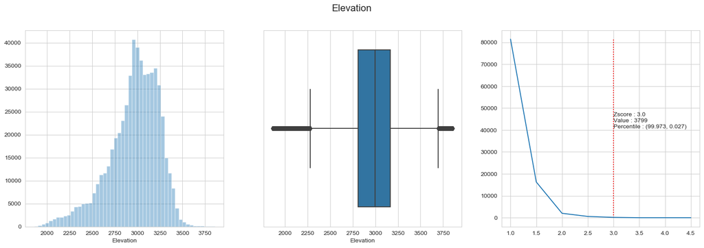

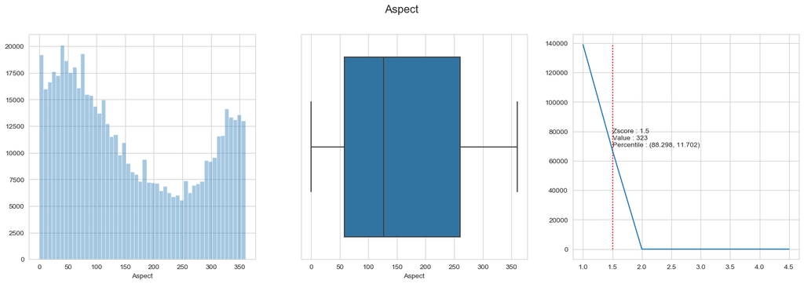

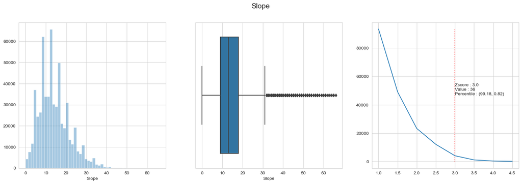

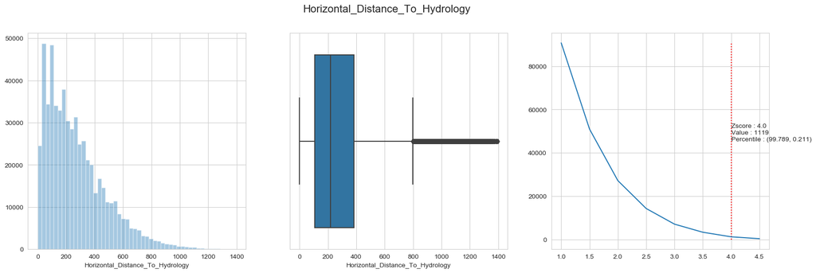

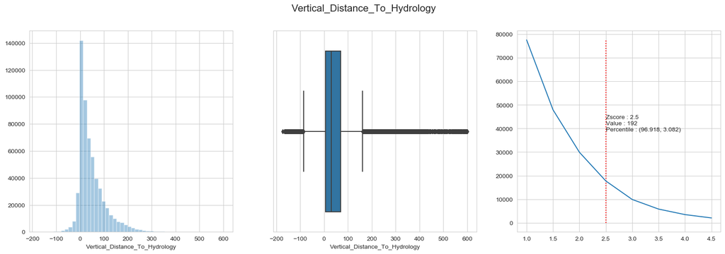

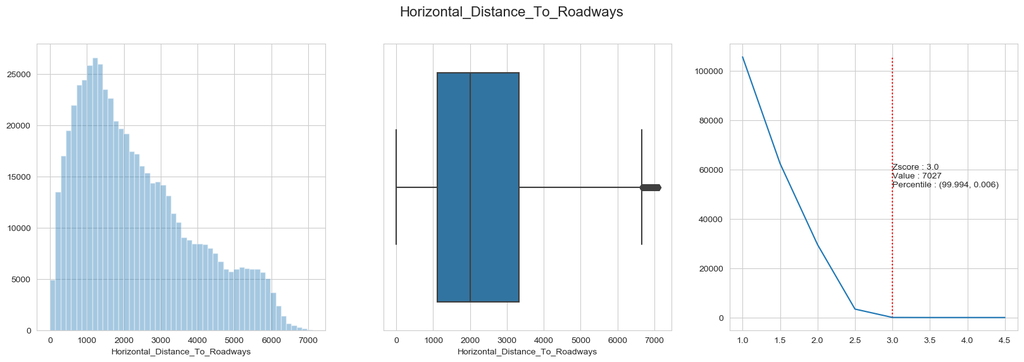

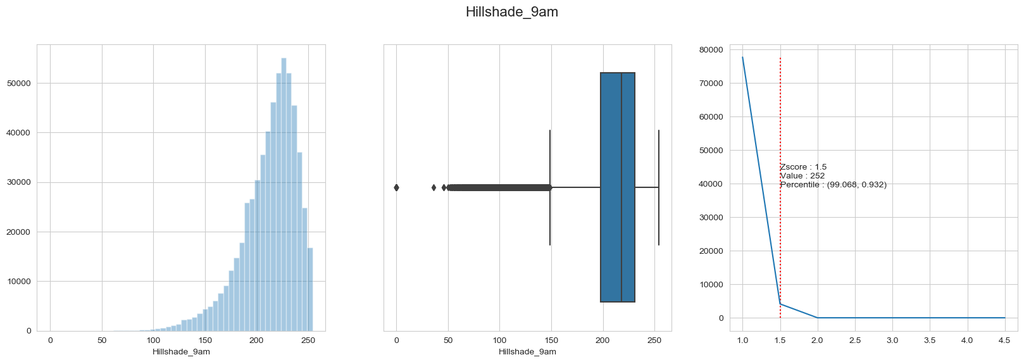

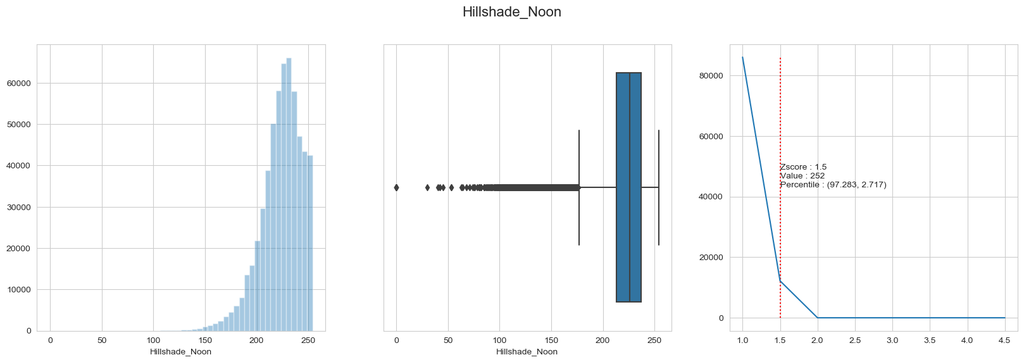

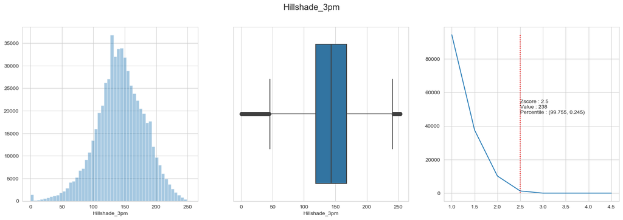

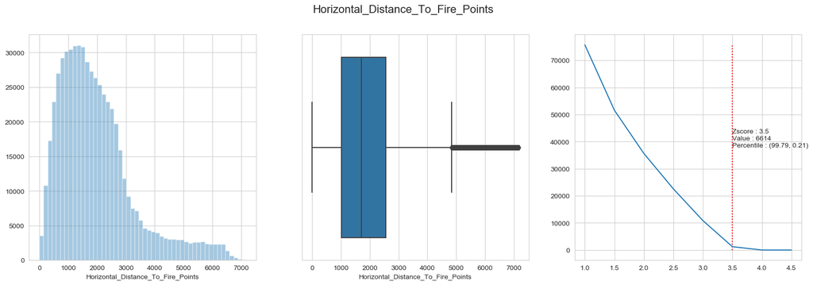

```python
for col in numeric:
    outlier_inspect(tree, col)
```

### Summary results :

> - If you focus on the plots on right side, you should realize that vertical red line indicates the `IQR` distance (`zscore`).
> - The `zscore` values vary from `1.5` to `4`. So I will choose `3` as `IQR` distance.
> - If your focus on the plots on the left side, you can see the skewness of each continuous column.

**Now, I want to check the outliers shape of continous features with respect to the target (`Cover_Type`) classes.**

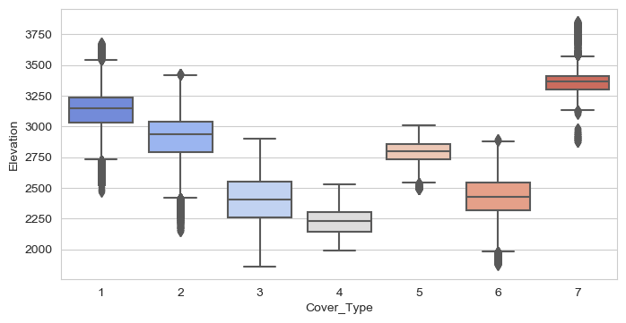

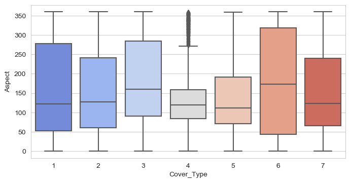

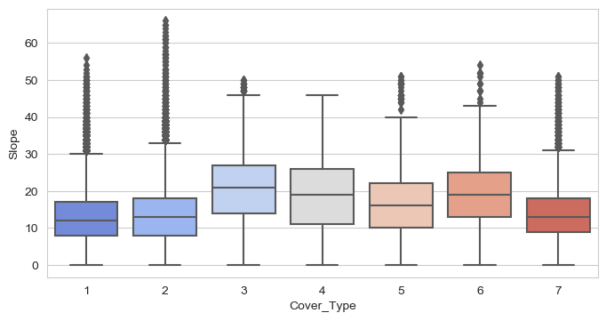

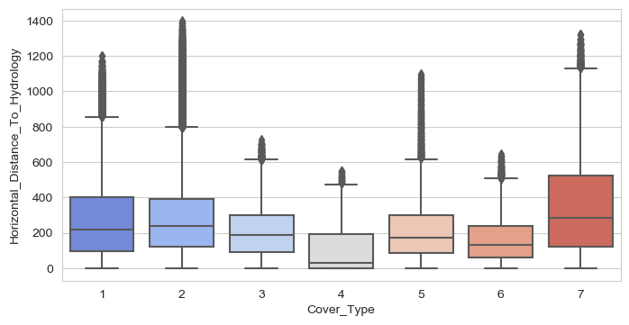

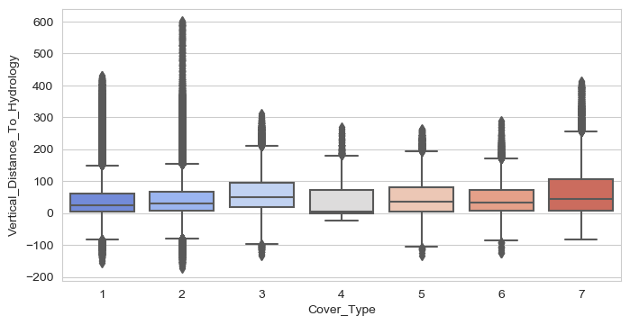

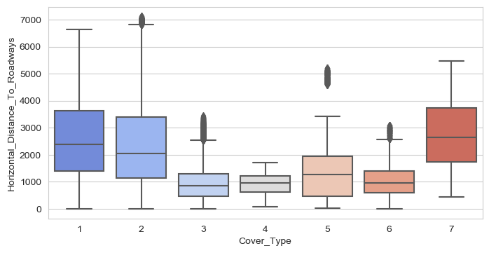

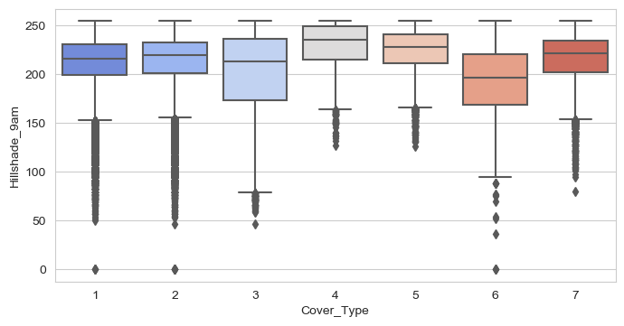

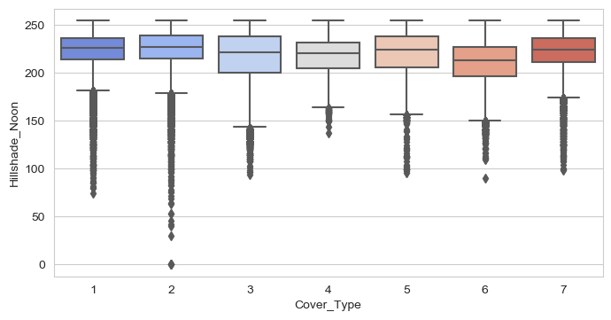

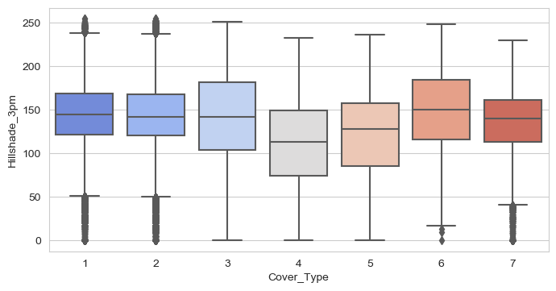

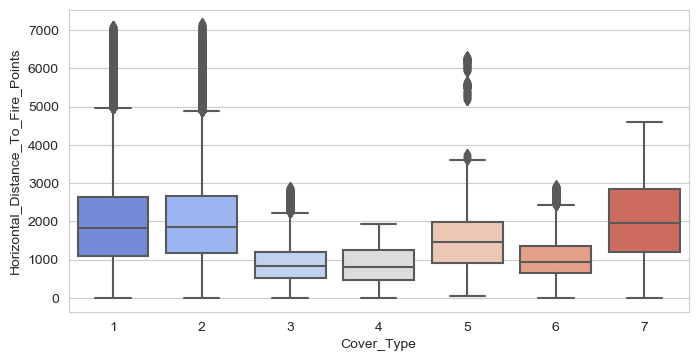

```python
tree['Cover_Type'] = tree['Cover_Type'].astype('category') #To convert target class into category

for i, col in enumerate(numeric):
    plt.figure(i, figsize=(8,4))
    sns.boxplot(x = tree['Cover_Type'], y=col, data=tree, palette="coolwarm")
```

```python
def detect_outliers(df, col_name):
    '''
    this function detects outliers based on 3 time IQR and
    returns the number of lower and uper limit and number of outliers respectively
    '''
    first_quartile = np.percentile(np.array(df[col_name].tolist()), 25)
    third_quartile = np.percentile(np.array(df[col_name].tolist()), 75)
    IQR = third_quartile - first_quartile

    upper_limit = third_quartile+(3*IQR)
    lower_limit = first_quartile-(3*IQR)
    outlier_count = 0

    for value in df[col_name].tolist():
        if (value < lower_limit) | (value > upper_limit):
            outlier_count +=1
    return lower_limit, upper_limit, outlier_count
```

**Let's see how many outliers are there of each Continuous Columns**

```python
for col in numeric:
    if detect_outliers(tree, col)[2] > 0:
        print("There are {} outliers in {}".format(detect_outliers(tree, col)[2], col))
```

```
There are 275 outliers in Slope
There are 414 outliers in Horizontal_Distance_To_Hydrology
There are 5339 outliers in Vertical_Distance_To_Hydrology
There are 1027 outliers in Hillshade_9am
There are 1191 outliers in Hillshade_Noon
There are 10 outliers in Horizontal_Distance_To_Fire_Points
```

### According to the plotting and analysis above, we should focus on the following columns in terms of outliers :

- There are 275 outliers in `Slope`
- There are 414 outliers in `Horizontal_Distance_To_Hydrology`
- There are 5339 outliers in `Vertical_Distance_To_Hydrology`
- There are 10 outliers in `Horizontal_Distance_To_Fire_Points`

### I will drop all rows which contain outliers in these four colums above

```python
tree1 = tree[(tree['Slope'] > detect_outliers(tree, 'Slope')[0]) &
              (tree['Slope'] < detect_outliers(tree, 'Slope')[1])]
tree1.shape
```

```
(580640, 55)
```

```python
tree1 = tree1[(tree1['Horizontal_Distance_To_Fire_Points'] > detect_outliers(tree1, 'Horizontal_Distance_To_Fire_Points')[0]) &
              (tree1['Horizontal_Distance_To_Fire_Points'] < detect_outliers(tree1, 'Horizontal_Distance_To_Fire_Points')[1])]

tree1.shape
```

```
(580630, 55)
```

```python
tree1 = tree1[(tree1['Horizontal_Distance_To_Hydrology'] > detect_outliers(tree1, 'Horizontal_Distance_To_Hydrology')[0]) &
              (tree1['Horizontal_Distance_To_Hydrology'] < detect_outliers(tree1, 'Horizontal_Distance_To_Hydrology')[1])]

tree1.shape
```

```
(580216, 55)
```

```python
tree1 = tree1[(tree1['Vertical_Distance_To_Hydrology'] > detect_outliers(tree1, 'Vertical_Distance_To_Hydrology')[0]) &
              (tree1['Vertical_Distance_To_Hydrology'] < detect_outliers(tree1, 'Vertical_Distance_To_Hydrology')[1])]

tree1.shape
```

```
(574967, 55)
```

#### We dropped 6045 rows totally which contain outlier values

```python
len(tree) - len(tree1)
```

```
6045
```

```python
tree1 = tree1.reset_index(drop=True)
```

### Continue to EDA

- I should check the relation between `Wilderness Areas` & `Soil Types` in terms of Types of Trees(`Cover_Type`)

**First, `Wilderness_Area`s :**

```python
# it belongs to only one "Wilderness_Area"s at the same time.

total_area = tree1["Wilderness_Area1"] + tree1["Wilderness_Area2"] + tree1["Wilderness_Area3"] + tree1["Wilderness_Area4"]
print(total_area.value_counts())
```

```
1    574967
dtype: int64
```

**Second, `Soil_Type`s :**

```python
soil_columns = [i for i in tree1.columns if "Soil" in i]
```

```python
# sum of all soil type columns' values
total_soil = 0
for x in [i for i in tree1.columns if "Soil" in i]:
    total_soil += tree1[x]
```

```python
# it belongs to only one "Soil_Type"s at the same time.

print(total_soil.value_counts())
```

```
1    574967
Name: Soil_Type1, dtype: int64
```

### Summary results :

> - Yes, the analysis above prove that `Wilderness_Areas` and `Soil_Types` columns have only `1` or `0` and it belongs to only one `Soil_Type` or `Wilderness_Area` at the same time.
> - These columns are `get_dummied` (one-hot encoded) from categorical values.

### I want to explore the number of values counts within each Binary types

```python
binaries = tree1.loc[:,'Wilderness_Area1':'Soil_Type40']
```

```python
for col in binaries:
    count = binaries[col].value_counts()[1]
    print(col, count)
```

```
Wilderness_Area1 259664
Wilderness_Area2 29865
Wilderness_Area3 248652
Wilderness_Area4 36786
Soil_Type1 3017
Soil_Type2 7511
Soil_Type3 4818
Soil_Type4 12314
Soil_Type5 1597
Soil_Type6 6556
Soil_Type7 105
Soil_Type8 179
Soil_Type9 1147
Soil_Type10 32418
Soil_Type11 12382
Soil_Type12 29957
Soil_Type13 16871
Soil_Type14 599
Soil_Type15 3
Soil_Type16 2845
Soil_Type17 3422
Soil_Type18 1899
Soil_Type19 4021
Soil_Type20 9259
Soil_Type21 838
Soil_Type22 33370
Soil_Type23 57698
Soil_Type24 21063
Soil_Type25 474
Soil_Type26 2589
Soil_Type27 792
Soil_Type28 766
Soil_Type29 114948
Soil_Type30 29960
Soil_Type31 25236
Soil_Type32 51895
Soil_Type33 43783
Soil_Type34 1583
Soil_Type35 1891
Soil_Type36 119
Soil_Type37 298
Soil_Type38 15533
Soil_Type39 13668
Soil_Type40 7543
```

**I decided to choose a limit of just over 1000 values. Let's examine negligible `Soil_Types` that have less than 1100 values.**

```python
[[col, binaries[col].value_counts()[1]] for col in binaries if [col, binaries[col].value_counts()[1]][1]<1100]
```

```
[['Soil_Type7', 105],
 ['Soil_Type8', 179],
 ['Soil_Type14', 599],
 ['Soil_Type15', 3],
 ['Soil_Type21', 838],
 ['Soil_Type25', 474],
 ['Soil_Type27', 792],
 ['Soil_Type28', 766],
 ['Soil_Type36', 119],
 ['Soil_Type37', 298]]
```

```python
[col for col in binaries if [col, binaries[col].value_counts()[1]][1]<1000]
```

```
['Soil_Type7',
 'Soil_Type8',
 'Soil_Type14',
 'Soil_Type15',
 'Soil_Type21',
 'Soil_Type25',
 'Soil_Type27',
 'Soil_Type28',
 'Soil_Type36',
 'Soil_Type37']
```

### My target column is `Cover_Type`. So let's take a close look at this column.

#### The `Cover_Type` column has unbalanced labels of values. The value distance is far away between type of `"1"` & `"2"` and the others.

```python
for i in range(1,8) :
    print("the shape of the value of", i, tree1[tree1["Cover_Type"] == i].shape)
```

```
the shape of the value of 1 (210004, 55)
the shape of the value of 2 (280193, 55)
the shape of the value of 3 (35546, 55)
the shape of the value of 4 (2741, 55)
the shape of the value of 5 (9453, 55)
the shape of the value of 6 (17345, 55)
the shape of the value of 7 (19685, 55)
```

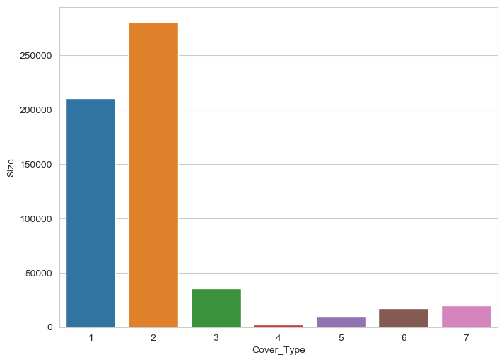

```python
class_tree = tree1.groupby('Cover_Type').size()
class_label = pd.DataFrame(class_tree,columns = ['Size'])
plt.figure(figsize = (8,6))
sns.barplot(x = class_label.index, y = 'Size', data = class_label)
```

- We can see that we have unbalanced data (`Cover_Type`). But, additionally I would like to check the distribution of each class of `Cover_Type` in terms of percentages.

```python
for i, number in enumerate(class_tree):
    percent = (number/class_tree.sum())
    print('Cover_Type', class_tree.index[i])
    print('%.2f'% percent)
```

```
Cover_Type 1
0.37
Cover_Type 2
0.49
Cover_Type 3
0.06
Cover_Type 4
0.00
Cover_Type 5
0.02
Cover_Type 6
0.03
Cover_Type 7
0.03
```

### Summary result:

> - I decided to keep the `Cover_Type` column as it is to see the different results in terms of the various ML Models' behavior to unbalanced data.

### Now, let's take a closer look at correlation of continuous columns.

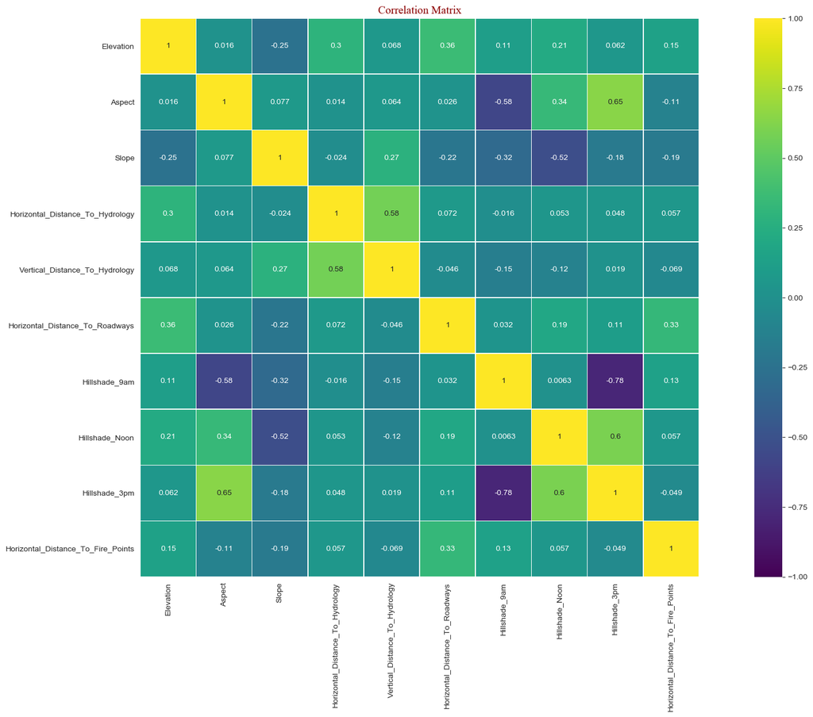

```python
corr_matrix = tree1[numeric].corr()

plt.figure(figsize=(25, 13))
sns.heatmap(corr_matrix,square=True, annot=True, linewidths=.5, vmin=-1, vmax=1, cmap='viridis')
plt.title("Correlation Matrix", fontdict=font_title)

plt.show()
```

### Summary results :

> - `Hillshade_3pm` and `Hillshade_9am` are highly correlated. So I decided to drop `Hillshade_3pm`.
> - `Horizontal_Distance_To_Hydrology` and `Vertical_Distance_To_Hydrology` columns somehow are not correlated (0.58) enough, so I decided to transform a new column derived from these two columns.
> - `Horizontal_Distance_To_Hydrology` and `Horizontal_Distance_To_Roadways` are not correlated (0.072) , so I decided to transform a new column derived from these two columns.
> - `Vertical_Distance_To_Hydrology` and `Elevation` are not correlated (0.068) , so I decided to transform a new column derived from these two columns.

**So far, we have implemented EDA process to recognize and analyze our dataset and made some decisions to adapt it to our models.**

```python
tree1.info()
```

```
<class 'pandas.core.frame.DataFrame'>
RangeIndex: 574967 entries, 0 to 574966
Data columns (total 55 columns):
 #   Column                              Non-Null Count   Dtype
---  ------                              --------------   -----
 0   Elevation                           574967 non-null  int64
 1   Aspect                              574967 non-null  int64
 2   Slope                               574967 non-null  int64
 3   Horizontal_Distance_To_Hydrology    574967 non-null  int64
 4   Vertical_Distance_To_Hydrology      574967 non-null  int64
 5   Horizontal_Distance_To_Roadways     574967 non-null  int64
 6   Hillshade_9am                       574967 non-null  int64
 7   Hillshade_Noon                      574967 non-null  int64
 8   Hillshade_3pm                       574967 non-null  int64
 9   Horizontal_Distance_To_Fire_Points  574967 non-null  int64
```

[output cut: 47 more lines]

**I saved the EDA-implemented dataset as `covtype_EDA` for importing into SQLite.**

```python
tree1.to_csv("covtype_EDA.csv", index = False)
```

**Now, its time to implement Feature Engineering using `SQLite`**

## Feature Engineering

### Now, let's do these process above using SQLite.

- Importing `covtype_EDA.csv` file into my local database in SQLite.

[figure not shown]

- Creating table named `"covtype_EDA"`

[figure not shown]

- Transforming new features on SQLite using the syntax below :

```
SELECT *,
(Horizontal_Distance_To_Hydrology*Horizontal_Distance_To_Hydrology)+(Vertical_Distance_To_Hydrology*Vertical_Distance_To_Hydrology) as Square_Hypo_Distance,
(Horizontal_Distance_To_Hydrology + Horizontal_Distance_To_Roadways)/2 as Average_Dist_Road_Hydro, (Elevation + Vertical_Distance_To_Hydrology) /2 as Average_Elevation_Hydro
FROM covtype_EDA;
```

[figure not shown]

- Saving the table (dataset of `covtype_EDA.csv`) as new table named `covtype1` on SQLite using the syntax below :

```
CREATE TABLE covtype1 as SELECT *,
(Horizontal_Distance_To_Hydrology*Horizontal_Distance_To_Hydrology)+(Vertical_Distance_To_Hydrology*Vertical_Distance_To_Hydrology) as Square_Hypo_Distance,
(Horizontal_Distance_To_Hydrology + Horizontal_Distance_To_Roadways)/2 as Average_Dist_Road_Hydro, (Elevation + Vertical_Distance_To_Hydrology)/2 as Average_Elevation_Hydro
FROM covtype_EDA;
```

[figure not shown]

- Selecting following required columns in SQLite :

```
SELECT Elevation, Aspect, Slope, Horizontal_Distance_To_Roadways, Hillshade_9am, Hillshade_Noon, Horizontal_Distance_To_Fire_Points, Wilderness_Area1, Wilderness_Area2, Wilderness_Area3,
Wilderness_Area4, Soil_Type1, Soil_Type2, Soil_Type3, Soil_Type4, Soil_Type5, Soil_Type6,
Soil_Type9, Soil_Type10, Soil_Type11, Soil_Type12, Soil_Type13, Soil_Type16, Soil_Type17,
Soil_Type18, Soil_Type19, Soil_Type20, Soil_Type22, Soil_Type23, Soil_Type24,
Soil_Type26, Soil_Type27, Soil_Type29, Soil_Type30, Soil_Type31, Soil_Type32, Soil_Type33,
Soil_Type34, Soil_Type35, Soil_Type38, Soil_Type39, Soil_Type40, Cover_Type,
Square_Hypo_Distance, Average_Dist_Road_Hydro, Average_Elevation_Hydro
FROM covtype1;
```

[figure not shown]

- Exporting transformed dataset (`covtype1`) from SQLite to local PC as `csv` file :

[figure not shown]

### Let's move to the second file (`02_ForestProject-Modeling&Presentation`) for modeling and presentation.